# Estadística Descriptiva

Eduardo Marín Nicolalde

_eemarin@espe.edu.ec_

# 1. Medidas de Tendencia Central

Promedio

```r
y = rnorm(250, 25, 5)
```

```r
media = mean(y)
	 media
```

25.2467574948958

La mediana

```r
mediana = median(y)
	mediana
```

25.4889022980101

La moda no tiene una función predefinida por lo que utilizaremos una **tabla de frecuencias** para encontrarla. La función `table()` crea una tabla de frecuencias contando el número de veces que un valor dado aparece en un vector/columna. Supongamos el siguiente vector:

```r
a = c(1:20, 5:10, 7 )
	a
```

1. 1

2. 2

3. 3

4. 4

5. 5

6. 6

7. 7

8. 8

9. 9

10. 10

11. 11

12. 12

13. 13

14. 14

15. 15

16. 16

17. 17

18. 18

19. 19

20. 20

21. 5

22. 6

23. 7

24. 8

25. 9

26. 10

27. 7

La función `table(a)` devuelve el número de veces que cada valor aparece en el vector, ordenando los valores de menor a mayor

```r
table(a)
```

```
a
 1  2  3  4  5  6  7  8  9 10 11 12 13 14 15 16 17 18 19 20
 1  1  1  1  2  2  3  2  2  2  1  1  1  1  1  1  1  1  1  1
```

Para facilitar la localización de la moda, podemos utilizar la función `sort(x, decreasing = TRUE)` de forma que el valor que más se repite, aparezca en primer lugar. En nuestro ejemplo, aparece primero el número `7` con 3 repeticiones.

```r
sort(table(a),decreasing=T)
```

```
a
 7  5  6  8  9 10  1  2  3  4 11 12 13 14 15 16 17 18 19 20
 3  2  2  2  2  2  1  1  1  1  1  1  1  1  1  1  1  1  1  1
```

Si existen demasiados valores, podemos utilizar la función `head()` para mostrar solamente los primeros 6 valores

```r
head(sort(table(a),decreasing=T))
```

```
a
 7  5  6  8  9 10
 3  2  2  2  2  2
```

Para el vector `y`, la moda no existe

```r
head(sort(table(y),decreasing=T))
```

```
y
 11.903510637579 13.2151552107145 13.3471493086612  13.816806245611
               1                1                1                1
14.8675016905175 14.8967379139737
               1                1
```

El Rango Medio puede calcularse con las funciones `max()` y `min()` que devuelven el máximo y el mínimo respectivamente

```r
rango.medio = (max(y) + min (y))/2
	rango.medio
```

25.0040492157784

Un resumen de los cálculos realizados se puede obtener utilizando `rbind()` que organiza los datos en forma de filas

```r
rbind(media,mediana,rango.medio)
```

| media | 25.24676 |
| --- | --- |
| mediana | 25.48890 |
| rango.medio | 25.00405 |

## 2. Medidas de Dispersión

El rango

```r
rango = max(y)-min(y)
	rango
```

26.2010771563989

La varianza

```r
varianza = var(y)
	varianza
```

24.979917831786

La desviación estándar puede calcularse de dos formas:

```r
sqrt(var(y))
```

4.99799137972306

```r
desv.est = sd(y)
	desv.est
```

4.99799137972306

El coeficiente de variación

```r
coef.var = desv.est / media *100
	coef.var
```

19.796567463103

Resumen con `rbind()`

```r
rbind(rango,varianza,desv.est,coef.var)
```

| rango | 26.201077 |
| --- | --- |
| varianza | 24.979918 |
| desv.est | 4.997991 |
| coef.var | 19.796567 |

## 3. Medidas de Posición

Para encontrar un percentil del conjunto de datos, utilizamos la función:

`quantile(x, probs = seq(0, 1, 0.25) )`

Donde `probs` refleja el valor de $0 \le p \le 1$. De forma predefinida, obtenemos los cuartiles, el mínimo y el máximo

```r
quantile (y)
```

**0%**

11.903510637579

**25%**

22.0154193239699

**50%**

25.4889022980101

**75%**

28.7166082879528

**100%**

38.1045877939779

Para obtener el Quintil 2, $p=0.40$. Entonces

```r
quantile (y, 0.40)
```

**40%:** 24.1043772192165

Devuelve $Qt_2 = D_4 = P_{40}$

De valor a percentil, la fórmula requiere el conteo de todos los números inferiores al valor propuesto $x$. Supongamos que desemos saber el percentil al que representa el valor **26.13**. Para contar el número de valores inferiores al mismo escribimos:

```r
y <  26.13
```

1. TRUE

2. FALSE

3. FALSE

4. FALSE

5. FALSE

6. TRUE

7. TRUE

8. FALSE

9. TRUE

10. FALSE

11. FALSE

12. FALSE

13. TRUE

14. TRUE

15. FALSE

16. FALSE

17. TRUE

18. TRUE

19. TRUE

20. TRUE

21. TRUE

22. FALSE

23. TRUE

24. TRUE

25. FALSE

26. FALSE

27. FALSE

28. TRUE

29. TRUE

30. TRUE

31. TRUE

32. TRUE

33. TRUE

34. TRUE

35. FALSE

36. TRUE

37. TRUE

38. TRUE

39. FALSE

40. TRUE

41. TRUE

42. FALSE

43. TRUE

44. TRUE

45. TRUE

46. FALSE

47. TRUE

48. TRUE

49. TRUE

50. TRUE

51. TRUE

52. FALSE

53. TRUE

54. FALSE

55. FALSE

56. FALSE

57. FALSE

58. TRUE

59. TRUE

60. FALSE

61. FALSE

62. TRUE

63. TRUE

64. FALSE

65. FALSE

66. TRUE

67. FALSE

68. TRUE

69. TRUE

70. FALSE

71. FALSE

72. TRUE

73. TRUE

74. FALSE

75. FALSE

76. FALSE

77. TRUE

78. TRUE

79. TRUE

80. FALSE

81. TRUE

82. FALSE

83. TRUE

84. FALSE

85. TRUE

86. FALSE

87. TRUE

88. FALSE

89. TRUE

90. TRUE

91. FALSE

92. FALSE

93. TRUE

94. FALSE

95. FALSE

96. TRUE

97. TRUE

98. TRUE

99. TRUE

100. TRUE

101. TRUE

102. TRUE

103. TRUE

104. FALSE

105. FALSE

106. TRUE

107. TRUE

108. TRUE

109. TRUE

110. TRUE

111. TRUE

112. FALSE

113. TRUE

114. TRUE

115. FALSE

116. TRUE

117. FALSE

118. FALSE

119. FALSE

120. TRUE

121. TRUE

122. TRUE

123. TRUE

124. FALSE

125. TRUE

126. FALSE

127. FALSE

128. TRUE

129. TRUE

130. TRUE

131. FALSE

132. TRUE

133. FALSE

134. TRUE

135. TRUE

136. FALSE

137. FALSE

138. TRUE

139. FALSE

140. TRUE

141. TRUE

142. TRUE

143. FALSE

144. FALSE

145. FALSE

146. TRUE

147. FALSE

148. FALSE

149. FALSE

150. TRUE

151. TRUE

152. FALSE

153. TRUE

154. TRUE

155. TRUE

156. FALSE

157. TRUE

158. FALSE

159. TRUE

160. FALSE

161. TRUE

162. FALSE

163. FALSE

164. FALSE

165. FALSE

166. FALSE

167. FALSE

168. TRUE

169. TRUE

170. FALSE

171. FALSE

172. TRUE

173. FALSE

174. FALSE

175. FALSE

176. FALSE

177. TRUE

178. TRUE

179. TRUE

180. TRUE

181. TRUE

182. FALSE

183. TRUE

184. TRUE

185. FALSE

186. FALSE

187. FALSE

188. FALSE

189. FALSE

190. TRUE

191. TRUE

192. TRUE

193. TRUE

194. TRUE

195. TRUE

196. TRUE

197. TRUE

198. TRUE

199. FALSE

200. TRUE

201. TRUE

202. FALSE

203. TRUE

204. TRUE

205. TRUE

206. FALSE

207. FALSE

208. FALSE

209. FALSE

210. FALSE

211. TRUE

212. TRUE

213. FALSE

214. FALSE

215. TRUE

216. TRUE

217. TRUE

218. FALSE

219. TRUE

220. FALSE

221. FALSE

222. TRUE

223. TRUE

224. TRUE

225. TRUE

226. TRUE

227. TRUE

228. FALSE

229. FALSE

230. FALSE

231. FALSE

232. TRUE

233. FALSE

234. TRUE

235. TRUE

236. FALSE

237. TRUE

238. TRUE

239. TRUE

240. FALSE

241. TRUE

242. TRUE

243. TRUE

244. FALSE

245. TRUE

246. TRUE

247. TRUE

248. TRUE

249. TRUE

250. FALSE

El resultado es un vector de tipo lógico donde `TRUE` significa que el valor en dicha posición cumple con la condición especificada. Para verificar qué valores cumplen con la condición, podemos concatenar los resultados:

```r
head(cbind(y,condicion = y <  26.13), 10)
```

| y | condicion |
| --- | --- |
| 13.21516 | 1 |
| 28.53689 | 0 |
| 27.37136 | 0 |
| 29.87844 | 0 |
| 31.01827 | 0 |
| 17.48548 | 1 |
| 22.83831 | 1 |
| 28.32133 | 0 |
| 14.89674 | 1 |
| 36.05380 | 0 |

En la concatenación, se obtiene un **1** si el valor cumple con la condición y **0** en caso contrario. Es decir, hemos aplicado la función indicatriz $$\sum_{i=1}^n {1}_{y_i<y}$$ Continuando con la fórmula, sacar el promedio del resultado de la función indicatriz y multiplicarlo por **100** devuelve el resultado deseado.

```r
mean(y <  26.13)*100
```

57.6

```r
sum(y <  26.13)/ length(y) * 100
```

57.6

## 4. Medidas de Forma

Para las medidas de forma, requerimos instalar y cargar la librería "PerformanceAnalytics"

```r
library(PerformanceAnalytics)
```

El coeficiente de asimetría se calcula con

```r
asimetria = skewness(y, method = c("sample"))
asimetria
```

-0.111312419171467

La exceso de curtosis se cálcula con

```r
curtosis = kurtosis(y, method = "sample_excess")
curtosis
```

-0.185388895710616

```r
rbind(asimetria,curtosis)
```

| asimetria | -0.1113124 |
| --- | --- |
| curtosis | -0.1853889 |

# 5. Muestreo Aleatorio Simple

Consideraremos el conjunto de datos iris —de dimensión 150 x 5— y extraeremos 60 filas con distintos procedimientos.

Para el muestreo aleatorio simple sin repetición, basta con hacer:

```r
indices <- sample( 1:nrow( iris ), 60 )
iris[ indices, ]
```

|  | Sepal.Length | Sepal.Width | Petal.Length | Petal.Width | Species |
| --- | --- | --- | --- | --- | --- |
| 34 | 5.5 | 4.2 | 1.4 | 0.2 | setosa |
| 73 | 6.3 | 2.5 | 4.9 | 1.5 | versicolor |
| 107 | 4.9 | 2.5 | 4.5 | 1.7 | virginica |
| 39 | 4.4 | 3.0 | 1.3 | 0.2 | setosa |
| 113 | 6.8 | 3.0 | 5.5 | 2.1 | virginica |
| 30 | 4.7 | 3.2 | 1.6 | 0.2 | setosa |
| 111 | 6.5 | 3.2 | 5.1 | 2.0 | virginica |
| 36 | 5.0 | 3.2 | 1.2 | 0.2 | setosa |
| 147 | 6.3 | 2.5 | 5.0 | 1.9 | virginica |
| 127 | 6.2 | 2.8 | 4.8 | 1.8 | virginica |
| 122 | 5.6 | 2.8 | 4.9 | 2.0 | virginica |
| 141 | 6.7 | 3.1 | 5.6 | 2.4 | virginica |
| 132 | 7.9 | 3.8 | 6.4 | 2.0 | virginica |
| 98 | 6.2 | 2.9 | 4.3 | 1.3 | versicolor |
| 56 | 5.7 | 2.8 | 4.5 | 1.3 | versicolor |
| 94 | 5.0 | 2.3 | 3.3 | 1.0 | versicolor |
| 11 | 5.4 | 3.7 | 1.5 | 0.2 | setosa |
| 7 | 4.6 | 3.4 | 1.4 | 0.3 | setosa |
| 135 | 6.1 | 2.6 | 5.6 | 1.4 | virginica |
| 3 | 4.7 | 3.2 | 1.3 | 0.2 | setosa |
| 121 | 6.9 | 3.2 | 5.7 | 2.3 | virginica |
| 123 | 7.7 | 2.8 | 6.7 | 2.0 | virginica |
| 114 | 5.7 | 2.5 | 5.0 | 2.0 | virginica |
| 120 | 6.0 | 2.2 | 5.0 | 1.5 | virginica |
| 82 | 5.5 | 2.4 | 3.7 | 1.0 | versicolor |
| 102 | 5.8 | 2.7 | 5.1 | 1.9 | virginica |
| 145 | 6.7 | 3.3 | 5.7 | 2.5 | virginica |
| 23 | 4.6 | 3.6 | 1.0 | 0.2 | setosa |
| 143 | 5.8 | 2.7 | 5.1 | 1.9 | virginica |
| 4 | 4.6 | 3.1 | 1.5 | 0.2 | setosa |
| 66 | 6.7 | 3.1 | 4.4 | 1.4 | versicolor |
| 124 | 6.3 | 2.7 | 4.9 | 1.8 | virginica |
| 105 | 6.5 | 3.0 | 5.8 | 2.2 | virginica |
| 112 | 6.4 | 2.7 | 5.3 | 1.9 | virginica |
| 38 | 4.9 | 3.6 | 1.4 | 0.1 | setosa |
| 31 | 4.8 | 3.1 | 1.6 | 0.2 | setosa |
| 83 | 5.8 | 2.7 | 3.9 | 1.2 | versicolor |
| 148 | 6.5 | 3.0 | 5.2 | 2.0 | virginica |
| 12 | 4.8 | 3.4 | 1.6 | 0.2 | setosa |
| 47 | 5.1 | 3.8 | 1.6 | 0.2 | setosa |
| 41 | 5.0 | 3.5 | 1.3 | 0.3 | setosa |
| 134 | 6.3 | 2.8 | 5.1 | 1.5 | virginica |
| 42 | 4.5 | 2.3 | 1.3 | 0.3 | setosa |
| 115 | 5.8 | 2.8 | 5.1 | 2.4 | virginica |
| 21 | 5.4 | 3.4 | 1.7 | 0.2 | setosa |
| 59 | 6.6 | 2.9 | 4.6 | 1.3 | versicolor |
| 110 | 7.2 | 3.6 | 6.1 | 2.5 | virginica |
| 26 | 5.0 | 3.0 | 1.6 | 0.2 | setosa |
| 126 | 7.2 | 3.2 | 6.0 | 1.8 | virginica |
| 99 | 5.1 | 2.5 | 3.0 | 1.1 | versicolor |
| 68 | 5.8 | 2.7 | 4.1 | 1.0 | versicolor |
| 78 | 6.7 | 3.0 | 5.0 | 1.7 | versicolor |
| 2 | 4.9 | 3.0 | 1.4 | 0.2 | setosa |
| 25 | 4.8 | 3.4 | 1.9 | 0.2 | setosa |
| 125 | 6.7 | 3.3 | 5.7 | 2.1 | virginica |
| 116 | 6.4 | 3.2 | 5.3 | 2.3 | virginica |
| 93 | 5.8 | 2.6 | 4.0 | 1.2 | versicolor |
| 14 | 4.3 | 3.0 | 1.1 | 0.1 | setosa |
| 101 | 6.3 | 3.3 | 6.0 | 2.5 | virginica |
| 149 | 6.2 | 3.4 | 5.4 | 2.3 | virginica |

Para relizar un muestreo aleatorio simple con repetición, basta con sustituir la variable indices anterior por

```r
indices <- sample( 1:nrow( iris ), 60, replace = TRUE )
iris[ indices, ]
```

|  | Sepal.Length | Sepal.Width | Petal.Length | Petal.Width | Species |
| --- | --- | --- | --- | --- | --- |
| 112 | 6.4 | 2.7 | 5.3 | 1.9 | virginica |
| 56 | 5.7 | 2.8 | 4.5 | 1.3 | versicolor |
| 49 | 5.3 | 3.7 | 1.5 | 0.2 | setosa |
| 67 | 5.6 | 3.0 | 4.5 | 1.5 | versicolor |
| 68 | 5.8 | 2.7 | 4.1 | 1.0 | versicolor |
| 18 | 5.1 | 3.5 | 1.4 | 0.3 | setosa |
| 9 | 4.4 | 2.9 | 1.4 | 0.2 | setosa |
| 149 | 6.2 | 3.4 | 5.4 | 2.3 | virginica |
| 53 | 6.9 | 3.1 | 4.9 | 1.5 | versicolor |
| 54 | 5.5 | 2.3 | 4.0 | 1.3 | versicolor |
| 59 | 6.6 | 2.9 | 4.6 | 1.3 | versicolor |
| 31 | 4.8 | 3.1 | 1.6 | 0.2 | setosa |
| 128 | 6.1 | 3.0 | 4.9 | 1.8 | virginica |
| 125 | 6.7 | 3.3 | 5.7 | 2.1 | virginica |
| 134 | 6.3 | 2.8 | 5.1 | 1.5 | virginica |
| 44 | 5.0 | 3.5 | 1.6 | 0.6 | setosa |
| 92 | 6.1 | 3.0 | 4.6 | 1.4 | versicolor |
| 20 | 5.1 | 3.8 | 1.5 | 0.3 | setosa |
| 102 | 5.8 | 2.7 | 5.1 | 1.9 | virginica |
| 8 | 5.0 | 3.4 | 1.5 | 0.2 | setosa |
| 113 | 6.8 | 3.0 | 5.5 | 2.1 | virginica |
| 7 | 4.6 | 3.4 | 1.4 | 0.3 | setosa |
| 61 | 5.0 | 2.0 | 3.5 | 1.0 | versicolor |
| 78 | 6.7 | 3.0 | 5.0 | 1.7 | versicolor |
| 28 | 5.2 | 3.5 | 1.5 | 0.2 | setosa |
| 12 | 4.8 | 3.4 | 1.6 | 0.2 | setosa |
| 71 | 5.9 | 3.2 | 4.8 | 1.8 | versicolor |
| 12.1 | 4.8 | 3.4 | 1.6 | 0.2 | setosa |
| 118 | 7.7 | 3.8 | 6.7 | 2.2 | virginica |
| 35 | 4.9 | 3.1 | 1.5 | 0.2 | setosa |
| 4 | 4.6 | 3.1 | 1.5 | 0.2 | setosa |
| 45 | 5.1 | 3.8 | 1.9 | 0.4 | setosa |
| 102.1 | 5.8 | 2.7 | 5.1 | 1.9 | virginica |
| 20.1 | 5.1 | 3.8 | 1.5 | 0.3 | setosa |
| 40 | 5.1 | 3.4 | 1.5 | 0.2 | setosa |
| 111 | 6.5 | 3.2 | 5.1 | 2.0 | virginica |
| 145 | 6.7 | 3.3 | 5.7 | 2.5 | virginica |
| 28.1 | 5.2 | 3.5 | 1.5 | 0.2 | setosa |
| 58 | 4.9 | 2.4 | 3.3 | 1.0 | versicolor |
| 143 | 5.8 | 2.7 | 5.1 | 1.9 | virginica |
| 144 | 6.8 | 3.2 | 5.9 | 2.3 | virginica |
| 143.1 | 5.8 | 2.7 | 5.1 | 1.9 | virginica |
| 33 | 5.2 | 4.1 | 1.5 | 0.1 | setosa |
| 66 | 6.7 | 3.1 | 4.4 | 1.4 | versicolor |
| 1 | 5.1 | 3.5 | 1.4 | 0.2 | setosa |
| 38 | 4.9 | 3.6 | 1.4 | 0.1 | setosa |
| 40.1 | 5.1 | 3.4 | 1.5 | 0.2 | setosa |
| 10 | 4.9 | 3.1 | 1.5 | 0.1 | setosa |
| 63 | 6.0 | 2.2 | 4.0 | 1.0 | versicolor |
| 32 | 5.4 | 3.4 | 1.5 | 0.4 | setosa |
| 5 | 5.0 | 3.6 | 1.4 | 0.2 | setosa |
| 137 | 6.3 | 3.4 | 5.6 | 2.4 | virginica |
| 54.1 | 5.5 | 2.3 | 4.0 | 1.3 | versicolor |
| 133 | 6.4 | 2.8 | 5.6 | 2.2 | virginica |
| 98 | 6.2 | 2.9 | 4.3 | 1.3 | versicolor |
| 53.1 | 6.9 | 3.1 | 4.9 | 1.5 | versicolor |
| 74 | 6.1 | 2.8 | 4.7 | 1.2 | versicolor |
| 45.1 | 5.1 | 3.8 | 1.9 | 0.4 | setosa |
| 49.1 | 5.3 | 3.7 | 1.5 | 0.2 | setosa |
| 139 | 6.0 | 3.0 | 4.8 | 1.8 | virginica |

# 6. Muestreo Aleatorio Estratificado

Para realizar muestreos estratificados con o sin reemplazamiento. La manera más sencilla de obtenerlos consiste en usar el paquete `sampling`.

El muestreo sin reemplazamiento y estratificado respecto a iris$Species —que es un factor con tres niveles de 50 elementos cada uno— puede llevarse a cabo así:

```r
library(sampling )
estratos <- strata( iris, stratanames = c("Species"), size = c(20,20,20), method = "srswor" )
iris.muestreado <- getdata( iris, estratos )
iris.muestreado
```

|  | Sepal.Length | Sepal.Width | Petal.Length | Petal.Width | Species | ID_unit | Prob | Stratum |
| --- | --- | --- | --- | --- | --- | --- | --- | --- |
| 1 | 5.1 | 3.5 | 1.4 | 0.2 | setosa | 1 | 0.4 | 1 |
| 3 | 4.7 | 3.2 | 1.3 | 0.2 | setosa | 3 | 0.4 | 1 |
| 4 | 4.6 | 3.1 | 1.5 | 0.2 | setosa | 4 | 0.4 | 1 |
| 5 | 5.0 | 3.6 | 1.4 | 0.2 | setosa | 5 | 0.4 | 1 |
| 8 | 5.0 | 3.4 | 1.5 | 0.2 | setosa | 8 | 0.4 | 1 |
| 10 | 4.9 | 3.1 | 1.5 | 0.1 | setosa | 10 | 0.4 | 1 |
| 15 | 5.8 | 4.0 | 1.2 | 0.2 | setosa | 15 | 0.4 | 1 |
| 17 | 5.4 | 3.9 | 1.3 | 0.4 | setosa | 17 | 0.4 | 1 |
| 24 | 5.1 | 3.3 | 1.7 | 0.5 | setosa | 24 | 0.4 | 1 |
| 27 | 5.0 | 3.4 | 1.6 | 0.4 | setosa | 27 | 0.4 | 1 |
| 30 | 4.7 | 3.2 | 1.6 | 0.2 | setosa | 30 | 0.4 | 1 |
| 34 | 5.5 | 4.2 | 1.4 | 0.2 | setosa | 34 | 0.4 | 1 |
| 36 | 5.0 | 3.2 | 1.2 | 0.2 | setosa | 36 | 0.4 | 1 |
| 40 | 5.1 | 3.4 | 1.5 | 0.2 | setosa | 40 | 0.4 | 1 |
| 41 | 5.0 | 3.5 | 1.3 | 0.3 | setosa | 41 | 0.4 | 1 |
| 42 | 4.5 | 2.3 | 1.3 | 0.3 | setosa | 42 | 0.4 | 1 |
| 44 | 5.0 | 3.5 | 1.6 | 0.6 | setosa | 44 | 0.4 | 1 |
| 48 | 4.6 | 3.2 | 1.4 | 0.2 | setosa | 48 | 0.4 | 1 |
| 49 | 5.3 | 3.7 | 1.5 | 0.2 | setosa | 49 | 0.4 | 1 |
| 50 | 5.0 | 3.3 | 1.4 | 0.2 | setosa | 50 | 0.4 | 1 |
| 53 | 6.9 | 3.1 | 4.9 | 1.5 | versicolor | 53 | 0.4 | 2 |
| 57 | 6.3 | 3.3 | 4.7 | 1.6 | versicolor | 57 | 0.4 | 2 |
| 58 | 4.9 | 2.4 | 3.3 | 1.0 | versicolor | 58 | 0.4 | 2 |
| 59 | 6.6 | 2.9 | 4.6 | 1.3 | versicolor | 59 | 0.4 | 2 |
| 63 | 6.0 | 2.2 | 4.0 | 1.0 | versicolor | 63 | 0.4 | 2 |
| 65 | 5.6 | 2.9 | 3.6 | 1.3 | versicolor | 65 | 0.4 | 2 |
| 68 | 5.8 | 2.7 | 4.1 | 1.0 | versicolor | 68 | 0.4 | 2 |
| 70 | 5.6 | 2.5 | 3.9 | 1.1 | versicolor | 70 | 0.4 | 2 |
| 73 | 6.3 | 2.5 | 4.9 | 1.5 | versicolor | 73 | 0.4 | 2 |
| 76 | 6.6 | 3.0 | 4.4 | 1.4 | versicolor | 76 | 0.4 | 2 |
| 78 | 6.7 | 3.0 | 5.0 | 1.7 | versicolor | 78 | 0.4 | 2 |
| 79 | 6.0 | 2.9 | 4.5 | 1.5 | versicolor | 79 | 0.4 | 2 |
| 80 | 5.7 | 2.6 | 3.5 | 1.0 | versicolor | 80 | 0.4 | 2 |
| 86 | 6.0 | 3.4 | 4.5 | 1.6 | versicolor | 86 | 0.4 | 2 |
| 87 | 6.7 | 3.1 | 4.7 | 1.5 | versicolor | 87 | 0.4 | 2 |
| 89 | 5.6 | 3.0 | 4.1 | 1.3 | versicolor | 89 | 0.4 | 2 |
| 91 | 5.5 | 2.6 | 4.4 | 1.2 | versicolor | 91 | 0.4 | 2 |
| 93 | 5.8 | 2.6 | 4.0 | 1.2 | versicolor | 93 | 0.4 | 2 |
| 94 | 5.0 | 2.3 | 3.3 | 1.0 | versicolor | 94 | 0.4 | 2 |
| 96 | 5.7 | 3.0 | 4.2 | 1.2 | versicolor | 96 | 0.4 | 2 |
| 104 | 6.3 | 2.9 | 5.6 | 1.8 | virginica | 104 | 0.4 | 3 |
| 110 | 7.2 | 3.6 | 6.1 | 2.5 | virginica | 110 | 0.4 | 3 |
| 112 | 6.4 | 2.7 | 5.3 | 1.9 | virginica | 112 | 0.4 | 3 |
| 113 | 6.8 | 3.0 | 5.5 | 2.1 | virginica | 113 | 0.4 | 3 |
| 114 | 5.7 | 2.5 | 5.0 | 2.0 | virginica | 114 | 0.4 | 3 |
| 116 | 6.4 | 3.2 | 5.3 | 2.3 | virginica | 116 | 0.4 | 3 |
| 117 | 6.5 | 3.0 | 5.5 | 1.8 | virginica | 117 | 0.4 | 3 |
| 122 | 5.6 | 2.8 | 4.9 | 2.0 | virginica | 122 | 0.4 | 3 |
| 123 | 7.7 | 2.8 | 6.7 | 2.0 | virginica | 123 | 0.4 | 3 |
| 124 | 6.3 | 2.7 | 4.9 | 1.8 | virginica | 124 | 0.4 | 3 |
| 127 | 6.2 | 2.8 | 4.8 | 1.8 | virginica | 127 | 0.4 | 3 |
| 128 | 6.1 | 3.0 | 4.9 | 1.8 | virginica | 128 | 0.4 | 3 |
| 130 | 7.2 | 3.0 | 5.8 | 1.6 | virginica | 130 | 0.4 | 3 |
| 131 | 7.4 | 2.8 | 6.1 | 1.9 | virginica | 131 | 0.4 | 3 |
| 138 | 6.4 | 3.1 | 5.5 | 1.8 | virginica | 138 | 0.4 | 3 |
| 139 | 6.0 | 3.0 | 4.8 | 1.8 | virginica | 139 | 0.4 | 3 |
| 141 | 6.7 | 3.1 | 5.6 | 2.4 | virginica | 141 | 0.4 | 3 |
| 142 | 6.9 | 3.1 | 5.1 | 2.3 | virginica | 142 | 0.4 | 3 |
| 148 | 6.5 | 3.0 | 5.2 | 2.0 | virginica | 148 | 0.4 | 3 |
| 150 | 5.9 | 3.0 | 5.1 | 1.8 | virginica | 150 | 0.4 | 3 |

Para obtener un muestreo con reemplazamiento se sustituye el método `srswor` por el `srswr`.

```r
estratos2 <- strata( iris, stratanames = c("Species"), size = c(20,20,20), method = "srswr" )
iris.muestreado2 <- getdata( iris, estratos2 )
iris.muestreado2
```

|  | Sepal.Length | Sepal.Width | Petal.Length | Petal.Width | Species | ID_unit | Prob | Stratum |
| --- | --- | --- | --- | --- | --- | --- | --- | --- |
| 4 | 4.6 | 3.1 | 1.5 | 0.2 | setosa | 4 | 0.332392 | 1 |
| 7 | 4.6 | 3.4 | 1.4 | 0.3 | setosa | 7 | 0.332392 | 1 |
| 8 | 5.0 | 3.4 | 1.5 | 0.2 | setosa | 8 | 0.332392 | 1 |
| 8.1 | 5.0 | 3.4 | 1.5 | 0.2 | setosa | 8 | 0.332392 | 1 |
| 11 | 5.4 | 3.7 | 1.5 | 0.2 | setosa | 11 | 0.332392 | 1 |
| 11.1 | 5.4 | 3.7 | 1.5 | 0.2 | setosa | 11 | 0.332392 | 1 |
| 12 | 4.8 | 3.4 | 1.6 | 0.2 | setosa | 12 | 0.332392 | 1 |
| 13 | 4.8 | 3.0 | 1.4 | 0.1 | setosa | 13 | 0.332392 | 1 |
| 14 | 4.3 | 3.0 | 1.1 | 0.1 | setosa | 14 | 0.332392 | 1 |
| 15 | 5.8 | 4.0 | 1.2 | 0.2 | setosa | 15 | 0.332392 | 1 |
| 16 | 5.7 | 4.4 | 1.5 | 0.4 | setosa | 16 | 0.332392 | 1 |
| 18 | 5.1 | 3.5 | 1.4 | 0.3 | setosa | 18 | 0.332392 | 1 |
| 19 | 5.7 | 3.8 | 1.7 | 0.3 | setosa | 19 | 0.332392 | 1 |
| 22 | 5.1 | 3.7 | 1.5 | 0.4 | setosa | 22 | 0.332392 | 1 |
| 22.1 | 5.1 | 3.7 | 1.5 | 0.4 | setosa | 22 | 0.332392 | 1 |
| 24 | 5.1 | 3.3 | 1.7 | 0.5 | setosa | 24 | 0.332392 | 1 |
| 28 | 5.2 | 3.5 | 1.5 | 0.2 | setosa | 28 | 0.332392 | 1 |
| 38 | 4.9 | 3.6 | 1.4 | 0.1 | setosa | 38 | 0.332392 | 1 |
| 40 | 5.1 | 3.4 | 1.5 | 0.2 | setosa | 40 | 0.332392 | 1 |
| 48 | 4.6 | 3.2 | 1.4 | 0.2 | setosa | 48 | 0.332392 | 1 |
| 51 | 7.0 | 3.2 | 4.7 | 1.4 | versicolor | 51 | 0.332392 | 2 |
| 52 | 6.4 | 3.2 | 4.5 | 1.5 | versicolor | 52 | 0.332392 | 2 |
| 70 | 5.6 | 2.5 | 3.9 | 1.1 | versicolor | 70 | 0.332392 | 2 |
| 76 | 6.6 | 3.0 | 4.4 | 1.4 | versicolor | 76 | 0.332392 | 2 |
| 76.1 | 6.6 | 3.0 | 4.4 | 1.4 | versicolor | 76 | 0.332392 | 2 |
| 77 | 6.8 | 2.8 | 4.8 | 1.4 | versicolor | 77 | 0.332392 | 2 |
| 78 | 6.7 | 3.0 | 5.0 | 1.7 | versicolor | 78 | 0.332392 | 2 |
| 78.1 | 6.7 | 3.0 | 5.0 | 1.7 | versicolor | 78 | 0.332392 | 2 |
| 82 | 5.5 | 2.4 | 3.7 | 1.0 | versicolor | 82 | 0.332392 | 2 |
| 83 | 5.8 | 2.7 | 3.9 | 1.2 | versicolor | 83 | 0.332392 | 2 |
| 84 | 6.0 | 2.7 | 5.1 | 1.6 | versicolor | 84 | 0.332392 | 2 |
| 86 | 6.0 | 3.4 | 4.5 | 1.6 | versicolor | 86 | 0.332392 | 2 |
| 87 | 6.7 | 3.1 | 4.7 | 1.5 | versicolor | 87 | 0.332392 | 2 |
| 93 | 5.8 | 2.6 | 4.0 | 1.2 | versicolor | 93 | 0.332392 | 2 |
| 96 | 5.7 | 3.0 | 4.2 | 1.2 | versicolor | 96 | 0.332392 | 2 |
| 96.1 | 5.7 | 3.0 | 4.2 | 1.2 | versicolor | 96 | 0.332392 | 2 |
| 97 | 5.7 | 2.9 | 4.2 | 1.3 | versicolor | 97 | 0.332392 | 2 |
| 97.1 | 5.7 | 2.9 | 4.2 | 1.3 | versicolor | 97 | 0.332392 | 2 |
| 99 | 5.1 | 2.5 | 3.0 | 1.1 | versicolor | 99 | 0.332392 | 2 |
| 99.1 | 5.1 | 2.5 | 3.0 | 1.1 | versicolor | 99 | 0.332392 | 2 |
| 101 | 6.3 | 3.3 | 6.0 | 2.5 | virginica | 101 | 0.332392 | 3 |
| 101.1 | 6.3 | 3.3 | 6.0 | 2.5 | virginica | 101 | 0.332392 | 3 |
| 105 | 6.5 | 3.0 | 5.8 | 2.2 | virginica | 105 | 0.332392 | 3 |
| 110 | 7.2 | 3.6 | 6.1 | 2.5 | virginica | 110 | 0.332392 | 3 |
| 110.1 | 7.2 | 3.6 | 6.1 | 2.5 | virginica | 110 | 0.332392 | 3 |
| 111 | 6.5 | 3.2 | 5.1 | 2.0 | virginica | 111 | 0.332392 | 3 |
| 111.1 | 6.5 | 3.2 | 5.1 | 2.0 | virginica | 111 | 0.332392 | 3 |
| 116 | 6.4 | 3.2 | 5.3 | 2.3 | virginica | 116 | 0.332392 | 3 |
| 118 | 7.7 | 3.8 | 6.7 | 2.2 | virginica | 118 | 0.332392 | 3 |
| 119 | 7.7 | 2.6 | 6.9 | 2.3 | virginica | 119 | 0.332392 | 3 |
| 123 | 7.7 | 2.8 | 6.7 | 2.0 | virginica | 123 | 0.332392 | 3 |
| 125 | 6.7 | 3.3 | 5.7 | 2.1 | virginica | 125 | 0.332392 | 3 |
| 127 | 6.2 | 2.8 | 4.8 | 1.8 | virginica | 127 | 0.332392 | 3 |
| 128 | 6.1 | 3.0 | 4.9 | 1.8 | virginica | 128 | 0.332392 | 3 |
| 129 | 6.4 | 2.8 | 5.6 | 2.1 | virginica | 129 | 0.332392 | 3 |
| 135 | 6.1 | 2.6 | 5.6 | 1.4 | virginica | 135 | 0.332392 | 3 |
| 135.1 | 6.1 | 2.6 | 5.6 | 1.4 | virginica | 135 | 0.332392 | 3 |
| 137 | 6.3 | 3.4 | 5.6 | 2.4 | virginica | 137 | 0.332392 | 3 |
| 145 | 6.7 | 3.3 | 5.7 | 2.5 | virginica | 145 | 0.332392 | 3 |
| 150 | 5.9 | 3.0 | 5.1 | 1.8 | virginica | 150 | 0.332392 | 3 |

Para ver técnicas de muestreo estratificado más sofisticadas se puede consultar la ayuda y ejemplos de la función `strata`.

# 7. Taller en Clase

Se dispone de una muestra de 10 personas para las que se han medido las variables:

- EDAD (en años)
- SEXO (codificada como 0: “Hombre”; 1:“Mujer”)
- NIVEL DE ESTUDIOS ( 0:“Sin estudios”; 1: “Estudios Primarios”; 2: “Estudios Secundarios”; 3:“Estudios Superiores”)

Con estos datos se desea:

1. Construir tablas de frecuencias unidimensionales para las tres variables.
2. Construir una tabla de frecuencias cruzadas con las variables ‘sexo’ y ‘nivel de estudios’.
3. Construir una tabla de frecuencias de la variable edad agrupada en intervalos.
4. Calcular media y desviación típica de la variable ‘edad’.
5. Calcular media y desviación típica de la variable ‘edad’ según sexo.

```r
edad=c(18,19,NA,18,24,17,22,15,22,25)
sexo=c(0,1,0,0,1,0,0,1,1,0)
estudios=c(1,2,0,1,3,2,3,1,2,3)
```

Recodificamos como factores el sexo y el nivel de estudios, asignando las etiquetas adecuadas:

```r
sexo=factor(sexo, levels=c(0,1),
                  labels=c("Hombre","Mujer"))

estudios=factor(estudios, levels=c(0,1,2,3),
                      labels=c("Sin estudios","Estudios Primarios",
                               "Estudios Secundarios","Estudios Superiores"))
```

Una vez que hemos introducido los datos procedemos a resolver la tarea que nos habíamos propuesto inicialmente.

A partir de ahora, mostramos los comandos que deberemos incluir en nuestro script para que R lleve a cabo las distintas tareas, así como los resultados que se obtienen.

## Tablas de frecuencias unidimensionales

1. Construir una tablas de frecuencias unidimensionales para las variables ‘sexo’ y ‘nivel de estudios’.

En R los comandos para la construcción de tablas son:

`table(nombre_de_variable)`: tablas de frecuencias absolutas.

`prop.table(table(nombre_de_variable))`: tablas de frecuencias relativas. Nótese aquí que la función prop.table() no opera directamente sobre la variable, sino sobre la tabla de frecuencias absolutas creada con `table()`. Esta es una característica habitual de R: utilizar funciones que operan sobre objetos creados previamente por otras funciones.

```r
table(edad)
```

```
edad
15 17 18 19 22 24 25
 1  1  2  1  2  1  1
```

```r
prop.table(table(edad))
```

```
edad
       15        17        18        19        22        24        25
0.1111111 0.1111111 0.2222222 0.1111111 0.2222222 0.1111111 0.1111111
```

Nótese que, por defecto, R no muestra cuantos valores perdidos hay en los datos. Para ello debemos utilizar la opción `useNA="ifany"`:

```r
table(edad,useNA="ifany")
```

```
edad
  15   17   18   19   22   24   25 <NA>
   1    1    2    1    2    1    1    1
```

### TRABAJO AUTÓNOMO: Construya tablas de frecuencias para las variables sexo y Nivel de estudios

# Tablas de frecuencias cruzadas

1. Construir una tabla de frecuencias cruzadas con las variables anteriores.

Las tablas de frecuencias cruzadas se construyen también con las funciones table() y prop.table(table()), especificando ahora las dos variables a cruzar.

Para las frecuencias relativas, en prop.table() incluimos un 1 si las queremos por filas, un 2 si por columnas, o nada si queremos las frecuencias relativas globales:

```r
table(estudios,sexo)
```

```
                      sexo
estudios               Hombre Mujer
  Sin estudios              1     0
  Estudios Primarios        2     1
  Estudios Secundarios      1     2
  Estudios Superiores       2     1
```

```r
prop.table(table(estudios,sexo))
```

```
                      sexo
estudios               Hombre Mujer
  Sin estudios            0.1   0.0
  Estudios Primarios      0.2   0.1
  Estudios Secundarios    0.1   0.2
  Estudios Superiores     0.2   0.1
```

```r
prop.table(table(estudios,sexo),1)
```

```
                      sexo
estudios                  Hombre     Mujer
  Sin estudios         1.0000000 0.0000000
  Estudios Primarios   0.6666667 0.3333333
  Estudios Secundarios 0.3333333 0.6666667
  Estudios Superiores  0.6666667 0.3333333
```

```r
prop.table(table(estudios,sexo),2)
```

```
                      sexo
estudios                  Hombre     Mujer
  Sin estudios         0.1666667 0.0000000
  Estudios Primarios   0.3333333 0.2500000
  Estudios Secundarios 0.1666667 0.5000000
  Estudios Superiores  0.3333333 0.2500000
```

# Tabla de frecuencias de una variable continua agrupada en intervalos.

La siguiente función nos indica que los valores de edad se sitúan en el rango de 15 a 25 años.

Una vez que hemos decidido el número de intervalos, generamos una secuencia de valores con los límites de cada intervalo y utilizamos la función cut() para que nos construya una nueva variable que recodifica la edad en dichos intervalos:

```r
range(edad,na.rm=TRUE)  # incluimos na.rm=TRUE para que ignore la presencia de valores perdidos
```

1. 15

2. 25

```r
nclass.Sturges(edad)  # Número de intervalos
```

5

```r
seq(15,25,length=nclass.Sturges(edad))  # Límites de los intervalos
```

1. 15

2. 17.5

3. 20

4. 22.5

5. 25

```r
# Construcción de los intervalos mediante la función cut():

intervalosEdad = cut(edad,breaks=seq(15,25,length=nclass.Sturges(edad)),include.lowest=TRUE)
intervalosEdad
```

1. (17.5,20]

2. (17.5,20]

3. <NA>

4. (17.5,20]

5. (22.5,25]

6. [15,17.5]

7. (20,22.5]

8. [15,17.5]

9. (20,22.5]

10. (22.5,25]

```r
# Por último construimos la tabla de frecuencias de esta variable:

table(intervalosEdad)
```

```
intervalosEdad
[15,17.5] (17.5,20] (20,22.5] (22.5,25]
        2         3         2         2
```

El paquete **agricolae** incluye la función `table.freq()` que construye la tabla de frecuencias para variables agrupadas en intervalos a partir de la información generada por la función hist() del paquete base de R.

Esta función dibuja un histograma.

| Lower | Upper | Main | Frequency | Percentage | CF | CPF |
| --- | --- | --- | --- | --- | --- | --- |
| 14 | 16 | 15 | 1 | 11.1 | 1 | 11.1 |
| 16 | 18 | 17 | 3 | 33.3 | 4 | 44.4 |
| 18 | 20 | 19 | 1 | 11.1 | 5 | 55.6 |
| 20 | 22 | 21 | 2 | 22.2 | 7 | 77.8 |
| 22 | 24 | 23 | 1 | 11.1 | 8 | 88.9 |
| 24 | 26 | 25 | 1 | 11.1 | 9 | 100.0 |

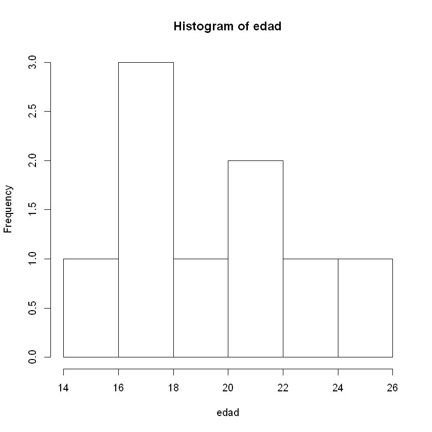

```r
library(agricolae)
tbFreqEdad = table.freq(hist(edad,plot=T))
tbFreqEdad
```

# Estadísticos descriptivos

1. Calcular media y desviación típica de la variable ‘edad’.

Las funciones disponibles en R para calcular estos estadísticos descriptivos son, respectivamente, mean(nombre_de_variable) y sd(nombre_de_variable):

```r
mean(edad)
```

<NA>

```r
sd(edad)
```

<NA>

### ¿Qué ha ocurrido aquí?

NA es el acrónimo para Not Available, esto es, para valores perdidos. Como la variable edad tiene valores perdidos, R “no puede” calcular su media ni su desviación típica, devolviéndonos un valor perdido.

De alguna manera R está “avisando” para que tengamos precaución (imaginemos que hemos medido 100 sujetos y sólo tenemos la edad de uno de ellos; la media sería ese único valor por lo que podría no estar describiendo adecuadamente la media de los datos).

¿Cómo hacer para “obligar” a R a que nos calcule la media y la desviación típica en presencia de valores perdidos?

### TRABAJO AUTÓNOMO: Ejecuta ?mean en la linea de comandos. Consulta la ayuda para descubrir de qué forma se consigue que R calcule la media en presencia de valores perdidos.

R dispone de una función genérica `summary()`, que cuando se aplica a una variable presenta un pequeño resumen descriptivo. Si la variable es numérica, dicho resumen incluye el mínimo, máximo, mediana, primer y tercer cuartiles, media y número de valores perdidos. Si la variable es de tipo factor, summary() muestra el número de observaciones en cada nivel del factor:

```r
summary(edad)
```

```
   Min. 1st Qu.  Median    Mean 3rd Qu.    Max.    NA's
     15      18      19      20      22      25       1
```

```r
summary(estudios)
```

**Sin estudios**

1

**Estudios Primarios**

3

**Estudios Secundarios**

3

**Estudios Superiores**

3

```r
summary(sexo)
```

**Hombre**

6

**Mujer**

4

Si las variables están contenidas en un data.frame la aplicación de summary() lleva a cabo un resumen descriptivo de todas las variables que contiene:

```r
misDatos = data.frame(edad,estudios,sexo)
summary(misDatos)
```

```
      edad                    estudios     sexo
 Min.   :15   Sin estudios        :1   Hombre:6
 1st Qu.:18   Estudios Primarios  :3   Mujer :4
 Median :19   Estudios Secundarios:3
 Mean   :20   Estudios Superiores :3
 3rd Qu.:22
 Max.   :25
 NA's   :1
```

### TRABAJO AUTÓNOMO: Ejecuta la función `describe(misDatos)` y observa como ahora la descripción se aplica a todas las variables de este data.frame.

Se debe cargar previamente la librería psych mediante library(psych)

# Resúmenes de datos por grupos.

1. Calcular media y desviación típica de la variable ‘edad’ por sexo.

Para ello utilizamos la función aggregate():

```r
aggregate(edad,by=list(sexo),mean)
```

| Group.1 | x |
| --- | --- |
| Hombre | NA |
| Mujer | 20 |

En el caso de los hombres nos encontramos nuevamente con el problema de los valores perdidos. Para obtener el resultado prescindiendo de dichos valores, es preciso utilizar la opción na.rm=TRUE (na.rm es un acrónimo de na remove):

```r
aggregate(edad,by=list(sexo),mean,na.rm=TRUE)
```

| Group.1 | x |
| --- | --- |
| Hombre | 20 |
| Mujer | 20 |

Existen algunas librerías o paquetes que contienen funciones más elaboradas para la obtención de estadísticos descriptivos de manera sencilla.

Por ejemplo, la librería psych contiene las funciones describe() y describe.by() que no sólo calculan la media sino que añaden otros estadísticos de interés.

### TRABAJO AUTÓNOMO. Ejecuta los siguientes comandos (cargar primero la librería psych si se ha hecho antes), y observa el resultado:

```r
library(psych)
describe(edad)
```

|  | vars | n | mean | sd | median | trimmed | mad | min | max | range | skew | kurtosis | se |
| --- | --- | --- | --- | --- | --- | --- | --- | --- | --- | --- | --- | --- | --- |
| X1 | 1 | 9 | 20 | 3.391165 | 19 | 20 | 4.4478 | 15 | 25 | 10 | 0.1025683 | -1.612056 | 1.130388 |

```r
describeBy(edad,sexo)
```

```
 Descriptive statistics by group
group: Hombre
   vars n mean   sd median trimmed  mad min max range skew kurtosis   se
X1    1 5   20 3.39     18      20 1.48  17  25     8 0.46    -1.86 1.52
------------------------------------------------------------
group: Mujer
   vars n mean   sd median trimmed  mad min max range  skew kurtosis   se
X1    1 4   20 3.92   20.5      20 3.71  15  24     9 -0.22    -2.05 1.96
```